# Compressed Sensing and Basis Pursuit

Kuan-I Lu, k_lu@ucsb.edu

2024-08-08

*Abstract* **—** The concept and idea of compressed sensing have become one of the most essential fundamentals for modern data science students. The development and application of compressed sensing have been present for several decades and have deeply rooted themselves in modern daily lives. To perform compressed sensing, the problem of signal decomposition arises, for which people over the years have come up with multiple approaches to handle this problem. Some of the underlying methods include Method of Frames (MOF), Matching Pursuit (MP), Best Orthogonal Basis (BOB), and most importantly, Basis Pursuit (BP). Each method is clever in its own way and reveals more mathematical and statistical problems respectively. What makes Basis Pursuit stand out the most is its ability to consistently reconstruct the signal with minimal error, and its ability to acquire a sparse representation of the signal in the form of coefficients of an overcomplete dictionary by minimizing the $l_1$ norm. In this paper, we will dive into the basics of all these methods of signal decomposition, grasping the basic concepts, along with some mathematical proofs and some code with real data to verify the properties of these methods. Also, we will touch on the case when noise is present, as well as the constraints and limitations of Basis Pursuit.

*Key words* **—** compressed sensing, basis pursuit, method of frames, matching pursuit, best orthogonal basis, linear program, $l_1$ norm optimization, overcomplete dictionary, wavelet packet dictionary, denoising, basis pursuit denoising, total variance denoising, R code

# 1. Introduction

We start from the given structure:

$X = \Psi \alpha$

where $X$ is the vectorized full signal(could be an image, audio, or anything), say $X$ is an $n \times 1$ vector.  
$\Psi$ is a universal basis(could be a Fourier basis, wavelet dictionary) that can explain a wide range of signals efficiently, $\Psi$ would be an $n \times n$ matrix.  
$\alpha$ is the coefficient of sparse representation of $X$ in terms of $\Psi$, $\alpha$ is an $n \times 1$ sparse vector.

The main problem compressed sensing is trying to solve is, How can we find the real $X$ with just a fraction of observation of $X$, say $s$, and $s = CX$? Well, if we can obtain $\alpha$, then we can just apply $X = \Psi \alpha$ to get $X$. So, the real question is, how do we make our best estimation of $\alpha$ inferred by $s$?

Here, instead of using an $n \times n$ universal basis $\Psi$, we’re using different overcomplete time-frequency dictionaries, $\Phi$, of size $n \times p$. This would help us to better explain $\alpha$. Some of the most used dictionaries are the wavelet packet dictionary and the cosine packet dictionary, having the property of both $\Phi$ and $\Phi ^T$ both being applied in order $O(nlog(n))$ time and order $O(nlog(n))$ space. Note that now the dimension of $\alpha$ become a $p \times 1$ vector.

# 2. Basis Persuit and Other Decomposition Methods

There are 4 main methods of decomposition: MOF, MP, BOB, and BP.[1]

## 2.1. Method of Frames (MOF)

### 2.1.1. Ideas and Solution

the objective of this method is to minimize the $l^2$ norm of $\alpha$:

$min ||\alpha||_2$ subject to $\Phi \alpha = s$

the solution is $\alpha^\dagger$ satisfying:

$\alpha^\dagger = \Phi^T(\Phi \Phi^T)^{-1}s$

### 2.1.2. Properties of MOF

MOF is not sparsity preserving. Although it provides an unique, stable solution, out goal is to obtain a sprase representation $\alpha$. so this method is not entirely ideal.

## 2.2. Matching Pursuit (MP)

### 2.2.1. Ideas and Solution

Matching Pursuit is an algorithm to address the sparsity goal of the result directly, starting from approximation $s^{(0)} = 0$ and $R^{(0)} = s$, we “match” the closest representation of our residual with an atom in our dictionary. The iteration is as described, for each iteration k:

$s^{(k)} = s^{(k-1)} + \alpha_k \phi_{\gamma k}$, where $\alpha_k = \langle R^{(k-1)}, \phi_{\gamma k} \rangle$ and $R^{(k)} = s - s^{(k)}$

iterate until the residual becomes sufficiently small.

### 2.2.2. Properties of MP

MP is simple and intuitive. However, although the nature of this matching process allows us to represent the signal using only a few (m) atoms after m iterations, it is too greedy and the computational cost of these inner products could be really high. Also MP could oversee the doublet structure of the input signal.

## 2.3. Best Orthogonal Basis (BOB)

### 2.3.1. Ideas and Solution

Best Orthogonal Basis selects an orthogonal basis from our dictionary, out of all the basis that the dictionary contains, that best represents the signal with the minimum representation cost, typically in terms of entropy or energy.

Define a cost function $C(B, s)$ that measures the representation cost of signal $s$ in basis $B$. We want to find the basis $B^*$ to minimize the cost:

$B^* = argmin_BC(B, s)$

### 2.3.2. Properties of BOB

One of the biggest disadvantage of BOB is in its name, the demand that BOB finds an orthogonal basis prevents $\alpha$ from being sparse. Also, if the dictionary we selected lacks time-varying structure, we might completely missed the structure of our input signal and finds nothing. Also, since the number of orthogonal baasis in a dictionary can be extremely large, the computaional cost could also be really high.

## 2.4. Basis Pursuit (BP)

### 2.4.1. Ideas and Solution

Basis Pursuit has a very similar idea with MOF, with one key difference. Instead of minimize the $l^2$ norm of $\alpha$, we minimize the $l^1$ norm to promote sparsity.

$min ||\alpha||_1$ subject to $\Phi \alpha = s$

Realize the problem presented can be viewed as a Linear Program(LP) essentially we’re solving $x \in \mathbb{R}^m$ by:

min $c^Tx$ subject to $Ax = B$, $x \geq 0$

where $c^Tx$ is the objective function, $Ax = B$ is a collection of equality constraint, and the relations $B \Leftrightarrow s$, $A \Leftrightarrow (\Phi, -\Phi)$ (concatenating the matrix $\Phi$ and the negation of it), $x \Leftrightarrow (u;v)$, $\alpha \Leftrightarrow u-v$, also $m \Leftrightarrow 2p$

### 2.4.2. Proof

**Theorem**:  
The BP goal

$min ||\alpha||_1$ subject to $\Phi \alpha = s$

is equivalent to solving the LP structure for

$x \in \mathbb{R}^m$ by minimizing

$c^Tx$ subject to $Ax = B$, $x \geq 0$

with the following translations:

$B \Leftrightarrow s$, $A \Leftrightarrow (\Phi, -\Phi)$, $x \Leftrightarrow (u;v)$, $\alpha \Leftrightarrow u-v$, $c \Leftrightarrow (1;1)$

**Lemma 1: Feasibility**:  
For any vector $\alpha$, there exist non-negative vectors $u, v$ such that:

$\alpha = u - v$, $u \geq 0, v \geq 0$

**Lemma 2: Relation between x and** $\alpha$:  
for a $2p$-dimensional vector $x \Leftrightarrow (u;v)$ (meaning x is a vertical concatenation of two $p$ dimension vector $u$ and $v$) and a $p$-dimensional vector $\alpha$:

If $x$ is sparse, then $\alpha$ is also sparse.

**Proof**:  
Linear Program requires an objective function to minimize, in order to find the $l_1$-norm of $\alpha$ we look at the objective function $c^T\alpha$ with $c$ being a $p$-dimensional vector with all-1 entries.

This cannot be true since LP requires the vector $\alpha$ to be non_negative. Therefore, we apply the translation $x \Leftrightarrow (u;v)$ with $\alpha = u - v$, $u \geq 0, v \geq 0$ (Lemma 1). Here, x is a $2p$-dimensional vector with the first $p$ entries being the vector $u$, and the last $p$ entries being the vector $v$.

Our new objective function becomes $c^Tx$, with $x$ satisfying the condition of being non-negative.

Now we define the matrix $A$ and the vector $b$ in the constraints of LP to align with the function $\Phi\alpha = s$ in BP. First set $A$ into a $n\times2p$ matrix since $x$ is a $2p\times 1$ vector. Define $A = (\Phi, -\Phi)$, here we have the result:

$Ax = \Phi u -\Phi v = \Phi (u - v) = \Phi\alpha = s$, and consequently $b = s$

Therefore, the Linear Program hold with the given the translations of variables.

Also, we can see $u$ and $v$ as two sparse coefficient of the dictionary representing the decomposed signal. Hence, $x$ is sparse, and according to Lemma 2, $\alpha$ is also sparse.

Furthermore, we would finally get the decomposition:

$s = \sum_{i=1}^{n}\alpha^\star_{\gamma_i}\phi_{\gamma_i}$, with $\phi_{\gamma_i}$ are independent but not necessarily orthogonal, and that the n columns of $\phi_{\gamma_i}$ constructs a basis of $\mathbb{R}^n$.

### 2.4.3. Algorithm for BP

We know that BP is essentially a linear program, and there are two main algorithms to solve it, which are BP-simplex and BP-interior, here’s the comparison and differences of these two algorithms, along with the pseudo algorithm of both methods.

**Simplex Method**:

This is the “standard” method to solve a linear program. The idea is intuitive, you find the feasible region of your constraint and you move along the edges to find the optimal vertex. Packages in R like `lpSolve` adapts this method. The algorithm is as follows[1]:

- Start with a feasible solution, typically we set non-basic variables to 0 and solve for the basic variables.
- Define the objective function, which is $c^Tx$, in other words, $\Sigma x_i$, since $c \Leftrightarrow (1;1)$.
- Define the constraints, which is $Ax = b$, and that $x_i \neq 0$ for all $i$.
- Iterate:
  - Select a non-basic variable to enter the basis using a pivot rule, for example, the largest coefficient in the objective function.
  - Identify the basic variable to leave the basis to maintain feasibility by computing the *minimum ratio test.*
  - Update the basis and the solution by performing a *pivot operation.*
- Terminate when there are no more negative coefficients in the objective function, indicating an optimal solution has been found

**Interior Method**:

In comparison to the simplex method, in stead of traversing through the edge of the constraints, interior method starts from inside of the simplex. With such iteration, the point gets closer to the boundary, where the solution lies, and eventually converges to the final value. Packages in R like `ROI` Utilizes this method. The algorithm is as follows[2]:

- Select an initial feasible point $x^{(0)}$ within the feasible region, and set a barrier parameter $\mu > 0$
- Formulate the barrier problem: $min ||x||_1 + \mu \Sigma_{i = 1}^{p}\phi(x_i)$, where $\phi(x_i) = -log(x_i)$ ensuring positive constraints.
- Iterate:
  - Solve the unconstrained minimization problem using *Newton’s method*, updating $x$ using the Newton-Raphson update: $x^{(k+1)} = x^{(k)}-\alpha(H(x^{(k)}))^{-1}\nabla f(x^{(k)})$
  - Decrease $\mu$ to reduce the influence of the barrier function, refining the solution for next iteration.
- Terminate when the barrier parameter $\mu$ is sufficiently small, meaning $x^{(k)}$ is sufficiently close to the solution.

### 2.4.4. Addition Notes on BP

BP cleverly promotes sparsity without a greedy approach. Out of all 4 methods, BP does the best at successfully recovering the sparse signal, under some constraints(e.g., Restricted Isometry Property). Also, note that BP is an optimization principle, not an algorithm.

# 3. Examples and Comparison

Here we test the performance of the aforementioned methods with different types of signal and analyse the result. We will choose to use the wavelet packet dictionary. Here we follow the definition of wavelet packet dictionary[1] to construct our overcomplete dictionary given n. Moreover, we develop the code for operating MOF and MP, and adapt the package `ADMM` which uses basis pursuit, using these functions we try to verify two facts[1], that BP has a more sparse representation of coefficients, and that BP tends to perform the best out of all methods.

## 3.1. MOF and BP

Here, we want to investigate the differences of the two closely related methods, MOF and BP, using the signal “A0” which takes the following form:

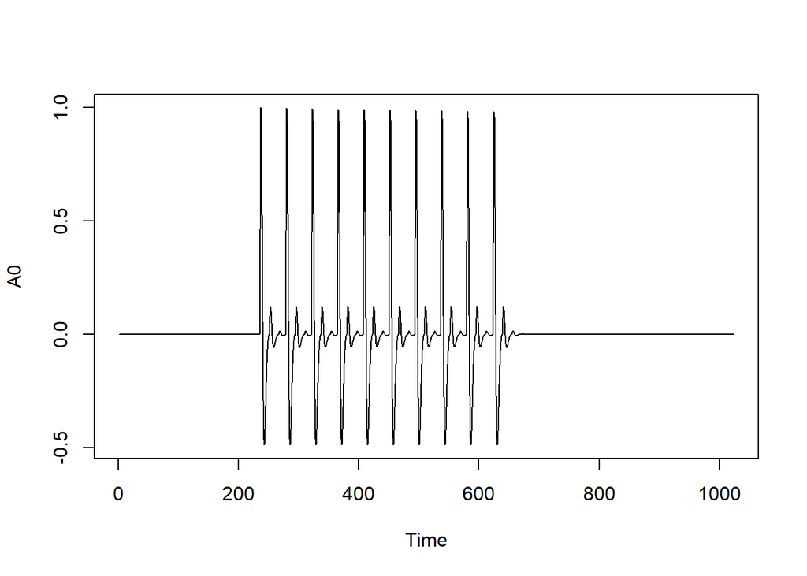

We fit the MOF model and the BP model and observe the response vector, $\alpha_{MOF}$ and $\alpha_{BP}$

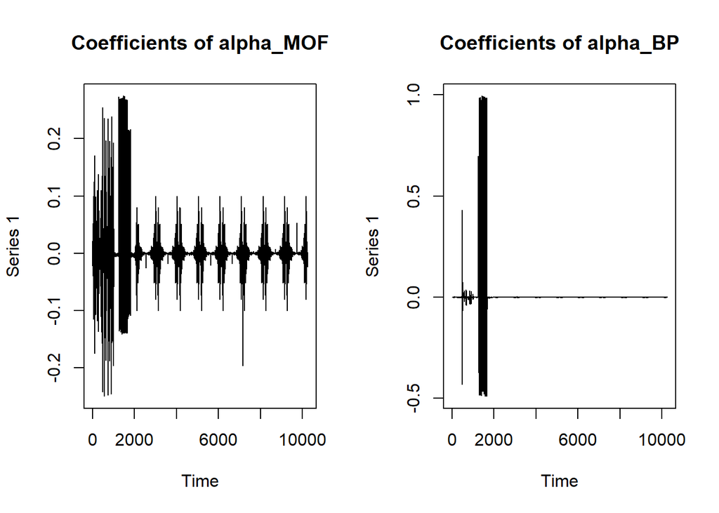

We confirm that, the coefficients of BP is indeed way sparser than that of MOF. Next, we look at the performance of the reconstructed signal, compare the time-frequency graph to the ideal case.

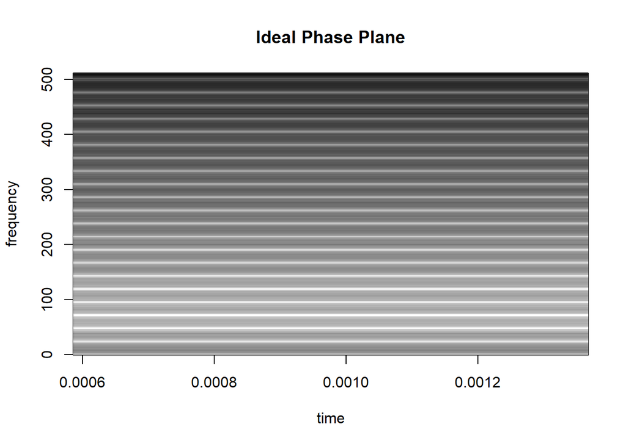

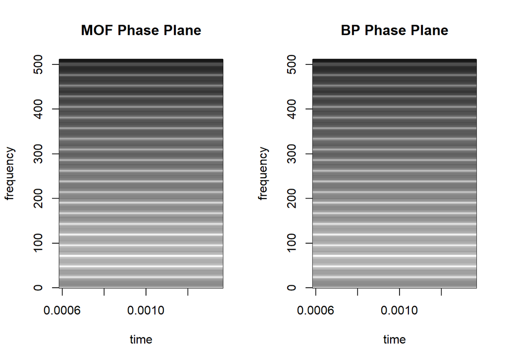

In this particular case, we can see that the performance of the two methods are rather similar, one major reason is that the observes signal we observed is complete, with the presence of noise, the BP would be expected to outperform MOF. Also, our goal is to obtain a sparse representation of the signal, so BP is still more favorable since $\alpha_{BP}$ is way more sparse. Also, note that BP takes significantly more time than MOF, this could be improved by using other algorithms to minimize the $l_1$ norm in BP.

```
## [1] "Running time for MOF: 14.33"
```

```
## [1] "Running time for BP: 115.7"
```

## 3.2. MP and BP

Moving on, We assess the differences of MP and BP, we know that MP prioritizes sparsity, but also has a few downsides. Therefore, we use the signal `twinsine` which is constructed with two sinusoids at two closely spaced frequency. The visualization of the signal is as follows:

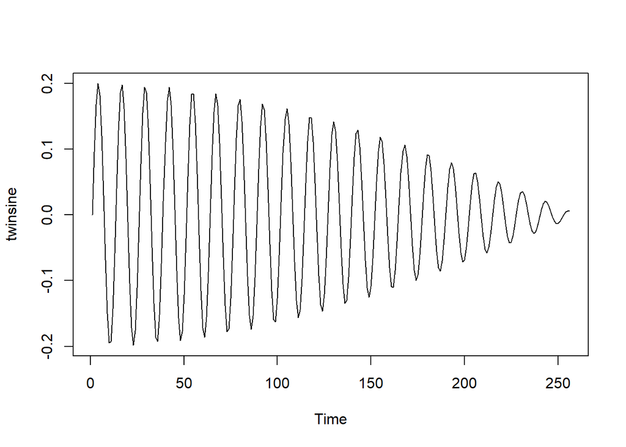

We now apply both MP and BP to the signal, we assess and compare the sparsity of the resulting vector of coefficient, $\alpha_{MP}$ and $\alpha_{BP}$.

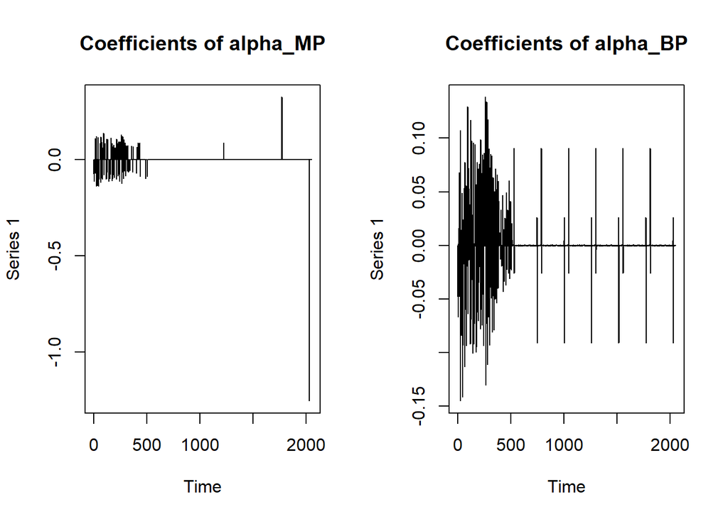

Indeed, MP has a far more sparse representation than that of BP. However, we need this representation to perform as well as BP for it to be considered a “better” method. Here we assess the phase plane of the two reconstructed signal along with the reconstructed signal themselves to compare the quality of the two methods.

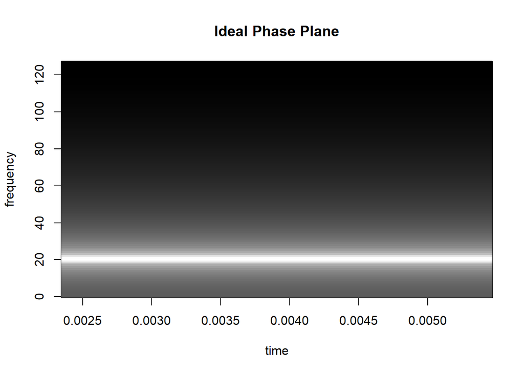

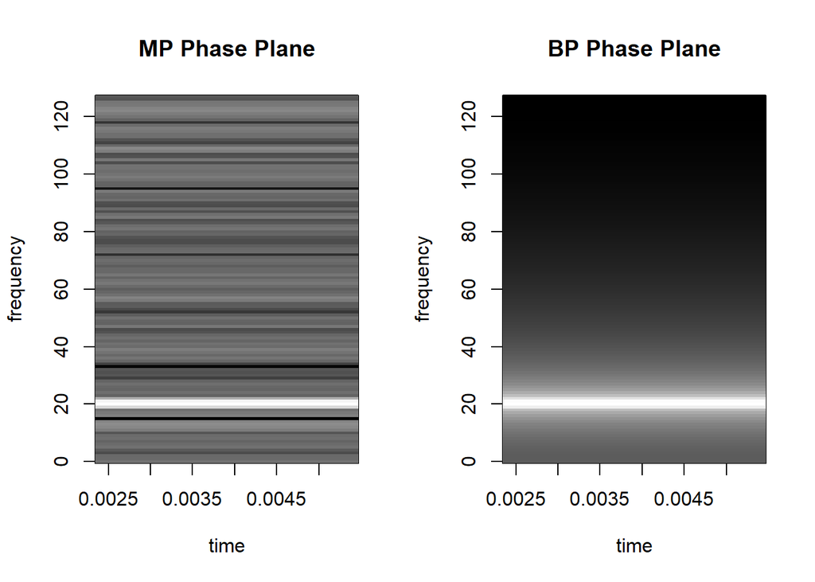

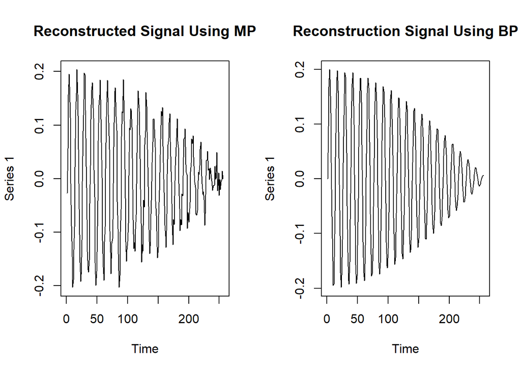

Compared to BP, MP didn’t do really well at reconstructing the signal, the signal is noisy and from the time-frequency graph we can see that MP included a lot of unnecessary atoms. This might be the case because MP missed the true frequency of the signal thus implemented many other incorrect atoms in its decomposition.

```
## [1] "Running time for MP: 0.409999999999997"
```

```
## [1] "Running time for BP: 2.19"
```

Comparing the running time for the two methods. Even though MP takes significantly less time than BP to operate, we would still consider BP to be the “better” method as there’s cases when the performance of MP is not consistent.

# 4. Denoising

### 4.1. Basis Pursuit Denoising(BPDN)

Essentially, BPDN extends the Basis Pursuit framework to handle noisy observations with the introduction of an error term to our signal and allow a small error in the reconstruction. Propose the data form:

$y = s + \sigma z$, with $z$ being a standard Gaussian white noise, $\sigma > 0$ is a noise level, and s is the clean signal. We observe $y$ in this case and $s$ is unknown.

BPDN tries to find the solution:

$min_a \frac{1}{2}||y-\Phi\alpha||^2_2+\lambda||\alpha||_1$

$\lambda$ controls the size of the residual with $\lambda_p = \sigma\sqrt{2log(p)}$ and $p$ being the number of rows of the dictionary.

Note that this is a perturbed linear program:

$min_a \frac{1}{2}\sum_\gamma(\tilde{y}-\alpha_\gamma)^2+\lambda\sum_\gamma|\alpha_\gamma|$

This yields a decomposition $y = s^{(\lambda)} + r^{(\lambda)}$, where $s^{(\lambda)} = \Phi\alpha^{(\lambda)}$

### 4.2. Total Variance Denoising

Instead of finding the minimum of $l_1$, TVD penalizes the least squared using the total variation:

$min_a \frac{1}{2}||y-g||^2_2+\lambda \cdot TV(g)$

Here, $TV(g)$ is a discrete measure of the total variation of $g$. The algorithm of this problem is based on the interior-point methods fr convex optimization.

### 4.3. Comparison

# 5. Constraints and Limitations

Although seemed powerful, there are also some constraints and limitation to keep in mind when working with Basis Pursuit on a compressed sensing problem, some of the limitation are as followed:

1. **Sparsity Requirement**: For compressed sensing to work, the signal observed has to be sparse or compressible in some domain. If the signal is not sparse or doesn’t have a sparse representation in any known basis, compressed sensing technique may not be effective. Specifically for BP, BP assumes that the signals can be exactly represented as a sparse combination of the dictionary atoms. In real life scenario, signals may only be approximately sparse.
2. **Restricted Isometric Property(RIP)**:  
   The dictionary $\Phi$ needs to satisfy RIP in order to recover sparse data. In particular, the matrix needs to preserves the length (norm) of all sparse signals within certain bounds. Ensuring that $\Phi$ satisfies RIP can be difficult, especially for certain types of matrices and large-scale problems.
3. **Choice of Dictionaries**:  
   For all the methods mentioned, we calculate with the assumption that the dictionaries used have fast implicit algorithms for $\Phi a$ and $\Phi^Ts$, leading to linear programs also with fast implicit algorithm for $Au$ and $A^Tv$. This limits our choice of dictionary to choose from. The good news is, using dictionaries that fits this narrative, such as the wavelet packet and the cosine packet, or the combination of other dictionaries that guarantees fast implicit algorithms, we can reach results that satisfies us.
4. **Measurement Noise**:  
   The level of noise in the observation can effect the result of the signal recovering process. Although processes like BPDN can deal with noise effectively, if the level of noise in the input signal is too high, the output signal might not be a good estimation of the real signal.
5. **Large Scale Linear Programs**: In BP, the goal is to minimize the $l_1$ norm and, in a large-scale setting, the LP computation can be demanding. There are some solutions to it, for example, the Primal-Dual Log-Barrier Algorithm, which takes an interior-point approach to tackle the large-scale problem within just a few iterations. However, such algorithms has its own constraints as well, say that matrix $A$ has to be sparse or assumptions of fast implicit algorithms for $Au$ and $A^Tv$. If the proposed solution doesn’t work efficiently or the requirements are not met, we take a step back MOF, and then make iterative improvements on it, which is computationally much easier. The goal of BP is to propose a method, given enough time to invest in, improves the performance over the MOF.

# 6. Conclusion

Throughout the sections of this paper, we’ve introduced the basics of these decomposition methods, proved some of the underlying mathematics, provided pseudo algorithms to solve the $l_1$ norm based on the works of previous scholars, tested the properties and differences of methods with self-developed code, and pointed out the constraints and cases when noise is present.

Numerous research questions arise after gaining a shallow yet broad understanding of this topic. Some of the questions include: Is there an optimal overcomplete dictionary to choose from, or does the choice of dictionary depend on the signal type? Are there any new methods developed 20 years after the publication of Basis Pursuit [1], or are there any refined versions of BP possible? What is the minimal level of signal (maximum level of noise) one can observe in order to still reconstruct the clean signal using these compressed sensing methods? What is the full picture and process of compressed sensing?

Some of these questions may have already been answered, while others might open up discussions and opportunities for further research. Without a doubt, understanding the basics makes me more curious about the undiscovered details and, at the same time, impressed by the work done by previous scholars. I am very excited to take my first step into the realm of compressed sensing knowledge, and I am also enthusiastic about the topics I plan to work on in the future. Lastly, I want to thank Prof. Gu for suggesting the topic and providing useful resources and guidelines that helped me navigate this project. All the support and constructive advice smoothed out the bumps on the journey of my first research paper.

**REFERENCES**

[1]S.S. Chen, D.L. Donoho, and M.A. Saunders, “Atomic Decomposition by Basis Pursuit,” *SIAM Review*, vol. 43, no. 1, 2001, pp. 129-159.

[2]S. Boyd and L. Vandenberghe, *Convex Optimization*, Cambridge University Press, 2004, pp. 561-568.

[3]D. Guo, Z. Liu, X. Qu, L. Huang, Y. Yao, and M.-T. Sun, “Sparsity-based Online Missing Data Recovery Using Overcomplete Dictionary”. source

[3]A. Qayyum, A.S. Malik, M.N.M. Saad, M. Mazher, F. Abdullah, and T.A.R.B.T. Abdullah, “Designing of Overcomplete Dictionaries Based on DCT and DWT,” in *2015 IEEE Student Symposium in Biomedical Engineering & Sciences (ISSBES)*, Shah Alam, Malaysia, 2015, pp. 134-139.